# Weight Lifting Exercises - Recognition of exercise execution quality

## Executive Summary

Six young health participants were asked to perform one set of 10 repetitions of the Unilateral Dumbbell Biceps Curl in five different fashions: exactly according to the specification (Class A), throwing the elbows to the front (Class B), lifting the dumbbell only halfway (Class C), lowering the dumbbell only halfway (Class D) and throwing the hips to the front (Class E).

The goal of this analysis is to predict “how (well)” an activity was performed. The “classe” variable in the training set contains manner in which the exercise was done.

Data are transformed using Principal Component Analysis and 4 machine learning models are trained and compared. Random Forest model is the most accurate with an accuracy of almost 100%.

## Data Loading and Patitioning

The training data set is partioned into 2 sets: training_initial (80%) and validation (20%). Validation set is going to be used for model testing.

```r
setwd("C:/Projects/R/Coursera/08.04.02_Assignment Course Project 1")
training_url    <- "https://d396qusza40orc.cloudfront.net/predmachlearn/pml-training.csv"
testing_url     <- "https://d396qusza40orc.cloudfront.net/predmachlearn/pml-testing.csv"
training_start  <- read.csv(url(training_url), na.strings=c("NA","#DIV/0!",""))
testing         <- read.csv(url(testing_url), na.strings=c("NA","#DIV/0!",""))
```

```r
library(caret)
validation_index    <- createDataPartition(training_start$classe, p=0.80, list=FALSE)
training_initial    <- training_start[validation_index,]
validation          <- training_start[-validation_index,]
```

## Data Cleaning

columns that have more than 90% NA values are removed from the training set.

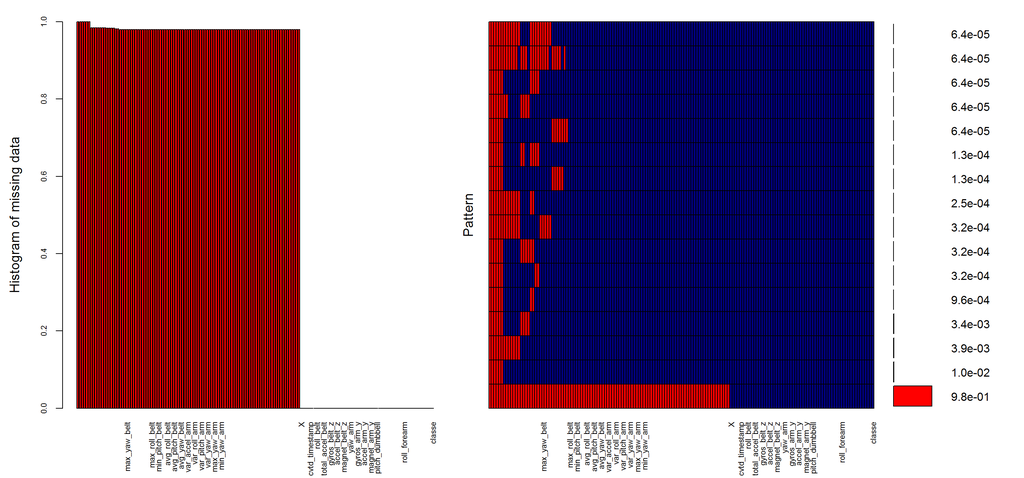

```
##
##  Variables sorted by number of missings:
##                  Variable     Count
##         kurtosis_yaw_belt 1.0000000
##         skewness_yaw_belt 1.0000000
##     kurtosis_yaw_dumbbell 1.0000000
##     skewness_yaw_dumbbell 1.0000000
##      kurtosis_yaw_forearm 1.0000000
##      skewness_yaw_forearm 1.0000000
##    kurtosis_picth_forearm 0.9841391
##    skewness_pitch_forearm 0.9841391
##     kurtosis_roll_forearm 0.9840754
##           max_yaw_forearm 0.9840754
##           min_yaw_forearm 0.9840754
##     amplitude_yaw_forearm 0.9840754
##  [ reached getOption("max.print") -- omitted 148 rows ]
```

```r
library(VIM)
aggr_plot <- aggr(training_initial, col=c('navyblue','red'), numbers=TRUE, sortVars=TRUE,
                   labels=names(training_initial), cex.axis=.7, gap=3, ylab=c("Histogram of missing data","Pattern"))
```

```r
not_na_columns <- aggr_plot$missings[aggr_plot$missings$Count<0.9*nrow(training_initial),"Variable"]
training_not_na <- subset(training_initial, select = c(not_na_columns))
```

First 7 column are irrelevant, so they are also removed.

```r
colnames(training_not_na[,c(1:7)])
```

```
## [1] "X"                    "user_name"            "raw_timestamp_part_1"
## [4] "raw_timestamp_part_2" "cvtd_timestamp"       "new_window"
## [7] "num_window"
```

```r
training_clean<-training_not_na[,-c(1:7)]
```

## Preprocessing

PCA is used in order to reduce dimensionality. PCA needed 26 components to capture 95 percent of the variance.

```r
preprocessParams <- preProcess(training_clean, method="pca")
training_transformed <- predict(preprocessParams,training_clean)
dim (training_transformed)
```

```
## [1] 15699    27
```

## Models Building

We will train the 4 machine learning models (Regression Trees, Random Forest, Generalized Boosted Regression Modeling and Support Vector Machine with Radial Basis Function) that we will compare. We will use transformed training data and repeated k-fold cross validation with 5 folds and 3 repeats (to evaluate the capability of the models on unseen data).

```r
trainControl <- trainControl(method="repeatedcv", number=5, repeats=3, allowParallel=TRUE)
metric <-"Accuracy"
```

```r
set.seed(2000)
fit.rpart <-train(classe~.,data=training_transformed,method="rpart", metric=metric, trControl=trainControl)
```

```r
set.seed(2000)
fit.rf <-train(classe~.,data=training_transformed,method="rf", metric=metric, trControl=trainControl)
```

```r
set.seed(2000)
fit.gbm <-train(classe~.,data=training_transformed,method="gbm", metric=metric, trControl=trainControl, verbose=FALSE)
```

```r
set.seed(2000)
fit.svmR <-train(classe~.,data=training_transformed,method="svmRadial", metric=metric, trControl=trainControl)
```

## Models Comparing

The estimated accuracy of the constructed models are compared.

```r
results <- resamples(list(RPART=fit.rpart, RF=fit.rf, GBM=fit.gbm, SVMR=fit.svmR)) #This function checks that the models are comparable and that they used the same training scheme (trainControl confguration).
summary(results)
```

```
##
## Call:
## summary.resamples(object = results)
##
## Models: RPART, RF, GBM, SVMR
## Number of resamples: 15
##
## Accuracy
##         Min. 1st Qu. Median   Mean 3rd Qu.   Max. NA's
## RPART 0.3825  0.3909 0.4069 0.4114  0.4285 0.4490    0
## RF    0.9707  0.9713 0.9729 0.9728  0.9736 0.9774    0
## GBM   0.7975  0.8039 0.8131 0.8128  0.8183 0.8286    0
## SVMR  0.9044  0.9070 0.9098 0.9100  0.9131 0.9182    0
##
## Kappa
##         Min. 1st Qu. Median   Mean 3rd Qu.   Max. NA's
## RPART 0.1713  0.1996 0.2265 0.2292  0.2591 0.3048    0
## RF    0.9629  0.9637 0.9657 0.9656  0.9666 0.9714    0
## GBM   0.7433  0.7516 0.7633 0.7628  0.7698 0.7830    0
## SVMR  0.8788  0.8821 0.8857 0.8859  0.8899 0.8963    0
```

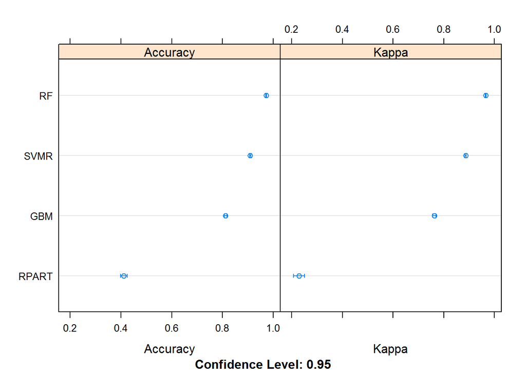

```r
dotplot(results)
```

Mean accuracy is the best for Random Forest model.

## Model Validation

In order to validate Random Forest model, we check model accuracy on validation set.

```r
validation_clean <- subset(validation,select = colnames(training_clean))
validation_transformed <- predict(preprocessParams,validation_clean)
pr.rf <- predict(fit.rf,validation_transformed)
cm.rf <- confusionMatrix(pr.rf, validation_transformed$classe)
cm.rf
```

```
## Confusion Matrix and Statistics
##
##           Reference
## Prediction    A    B    C    D    E
##          A 1116    4    0    0    0
##          B    0  753    2    0    0
##          C    0    2  681   11    1
##          D    0    0    1  632    1
##          E    0    0    0    0  719
##
## Overall Statistics
##
##                Accuracy : 0.9944
##                  95% CI : (0.9915, 0.9965)
##     No Information Rate : 0.2845
##     P-Value [Acc > NIR] : < 2.2e-16
##
##                   Kappa : 0.9929
##  Mcnemar's Test P-Value : NA
##
## Statistics by Class:
##
##                      Class: A Class: B Class: C Class: D Class: E
## Sensitivity            1.0000   0.9921   0.9956   0.9829   0.9972
## Specificity            0.9986   0.9994   0.9957   0.9994   1.0000
## Pos Pred Value         0.9964   0.9974   0.9799   0.9968   1.0000
## Neg Pred Value         1.0000   0.9981   0.9991   0.9967   0.9994
## Prevalence             0.2845   0.1935   0.1744   0.1639   0.1838
## Detection Rate         0.2845   0.1919   0.1736   0.1611   0.1833
## Detection Prevalence   0.2855   0.1925   0.1772   0.1616   0.1833
## Balanced Accuracy      0.9993   0.9957   0.9956   0.9911   0.9986
```

Since the accuracy is almost 100% and expected out of sample error is very small, model is not overfitted and it is going to be used for prediction of 20 test samples.

## Test Prediction

Finally, we can use our prediction model to predict 20 different test cases.

```r
testing_clean <- subset(testing, select = colnames(training_clean[,1:52]))
testing_transformed <- predict(preprocessParams,testing_clean)
pr.rf <- predict(fit.rf,testing_transformed)
pr.rf
```

```
##  [1] B A B A A E D B A A B C B A E E A B B B
## Levels: A B C D E
```